# results

# 4 Hypothetical Mitigation Action

We considered home elevations as a potential mitigation action. Households in the study area were raised above the 100-year floodplain one-by-one, with priority assigned based on their proximity to the Russian River. We iteratively recalculated the AAL until it fell below the target threshold of 50% of the original value. Calculations were performed on Sherlock, Stanford’s high-performance computing cluster, and results are stored in the `_results/mitigation` folder.

## 4.1 Calculate building-level losses for elevated case

```r
load('_results/final/_results/elevated/DV.Rdata')
loss.elevated <- loss.sim
```

[output not shown]

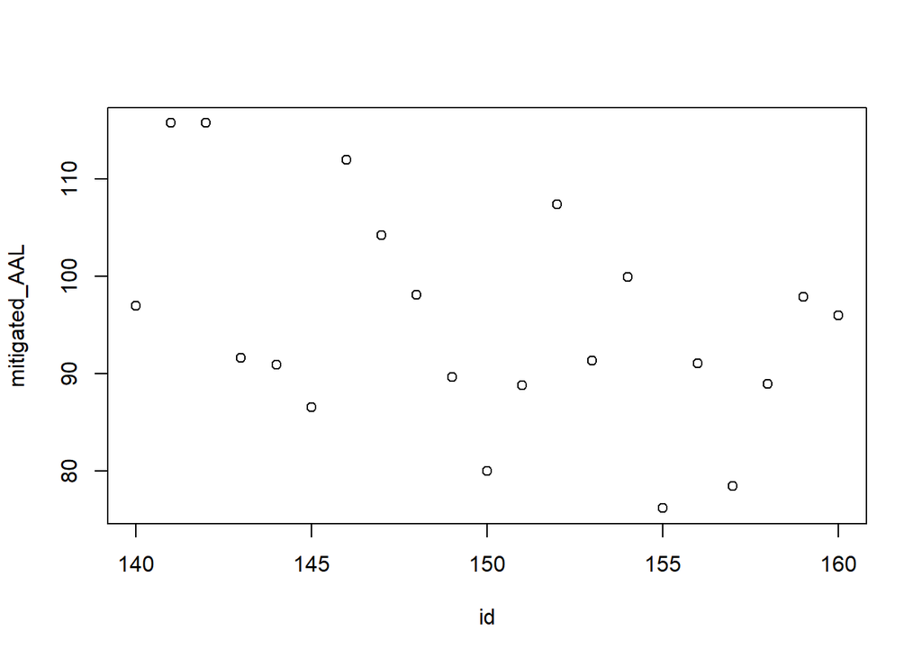

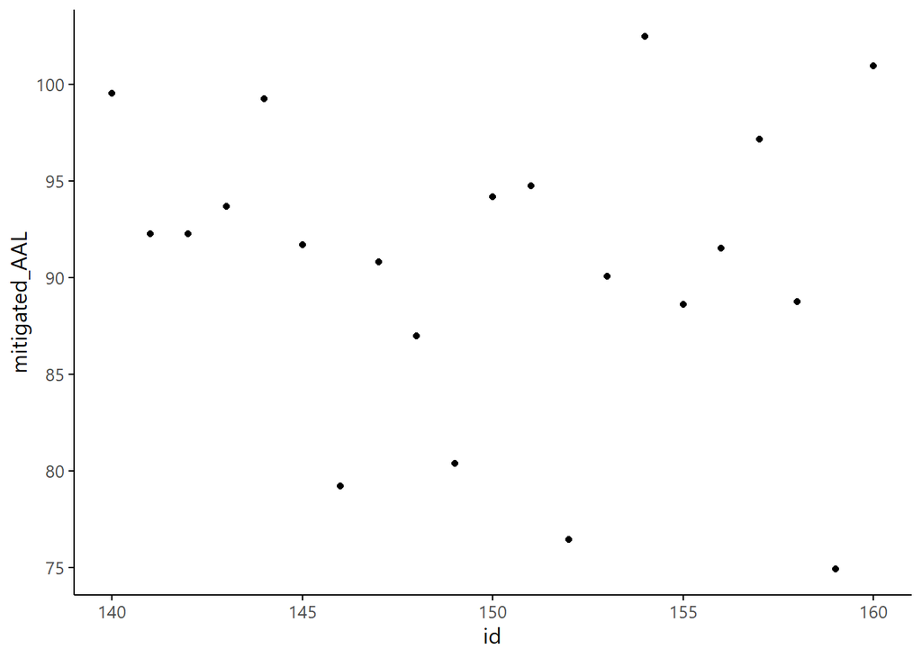

```r
## compare original AAL
load('_results/final/_results/mitigated/DV_dist_0.Rdata')
sum(loss.sim$loss)/3200/1e6

## compare elevated AAL
load('_results/final/_results/mitigated/DV_dist_1601.Rdata')
sum(loss.sim$loss)/3200/1e6

## look in the range of the recommended mitigation
id <- c(140:160)
mitigated_AAL <-
  foreach (i = id, .combine = 'c') %do% {
    load(paste0('_results/final/_results/mitigated/DV_dist_', i, '.Rdata'))
    sum(loss.sim$loss)/3200/1e6
  }
plot(id, mitigated_AAL)

mitigated_AAL <-
  foreach (i = id, .combine = 'c') %do% {
    load(paste0('_results/final/_results/mitigated/DV_dist_', i, '.Rdata'))
    sum(loss.group$loss)*nrow(loss.sim)/3200/1e6
  }
ggplot() +
  geom_point(aes(x = id, y = mitigated_AAL))
```

## 4.2 get mitigated loss exceedance curve

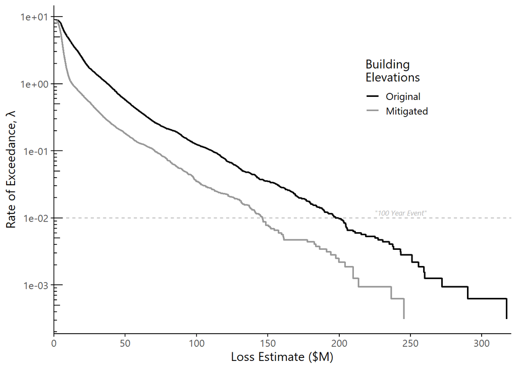

```r
load('_results/final/_results/mitigated/DV_dist_150.Rdata')
loss.mitigated <- loss.sim

## plot original vs. mitigated loss exceedance curve
ggplot() +
  geom_hline(yintercept = 1e-2, color = 'grey70', linetype = 'dashed') +
  annotate('text', x = 225e6, y = 1e-2, hjust = 0, vjust = -0.5,
           label = '"100 Year Event"', fontface = 'italic',
           family = 'Segoe UI', size = 7/.pt, color = 'grey70') +
  geom_step(aes(x = sort(loss.stochastic$loss),
                y = (nrow(loss.stochastic):1)/3200, color = 'Original'), size = 0.75) +
  geom_step(aes(x = sort(loss.mitigated$loss),
                y = (nrow(loss.mitigated):1)/3200, color = 'Mitigated'), size = 0.75) +
  scale_x_origin('Loss Estimate ($M)', breaks = seq(0, 5e8, 5e7),
                 labels = comma_format(scale = 1e-6)) +
  scale_y_log10('Rate of Exceedance, \u03bb', labels = scientific) +
  scale_color_manual('Building \nElevations', values = c('black', 'grey60'),
                     breaks = c('Original', 'Mitigated')) +
  annotation_logticks(sides = 'l') +
  theme(legend.position = c(0.75, 0.75))
ggsave('_figures/fig10_mitigated.png', width = 8.3, height = 6, units = 'cm')
```

```r
## calculate the mitigated AAL
sum(loss.stochastic$loss)/1e6/3200
sum(loss.mitigated$loss)/1e6/3200

## return period of 2019 event
p <- sum(loss.mitigated$loss > 91.6e6)/3200
percent(p, accuracy = 0.01)
comma(1/p, accuracy = 0.01)

## expected loss due to 1-in-100 year event
loss.mitigated %>%
  arrange(desc(loss)) %>%
  mutate(p = (1:nrow(.))/3200) %>%
  mutate(RP = 1/p) %>%
  filter(p == 0.01) %>%
  mutate(loss = loss/1e6) %>% pull(loss) %>%
  comma(prefix = '$', suffix = 'M', accuracy = 0.01)
```

```
## [1] 163.3064
## [1] 79.953
## [1] "4.91%"
## [1] "20.38"
## [1] "$146.25M"
```